# de_leon-clase2022

Romina De León

## Marcos teóricos y métodos cuantitativos para entender los grandes datos: Introudcción al análisis estadístico-estilístico de corpus en R

**Romina De León**

rdeleon@conicet.gov.ar

### ¿Qué es R?

R es un entorno de software libre (licencia GNU GLP), como lenguaje de programación interpretado, ejecuta las instrucciones directamente; además es gratuito y amigable de instalar y para trabajar, es muy utilizado para análisis estadístico y gráfica computacional.

Por su parte, R Studio es un entorno de desarrollo integrado para R, que cuenta con una consola, un editor de sintaxis para la ejecución de código, herramientas para el trazado, depuración y gestión del espacio de trabajo.

Ahora que ya sabemos de que se trata, comencemos con las instalaciones.

## Instalaciones previas

### ¿Cómo instalar R y R Studio?

#### Instalación de R

En este primer paso comenzaremos con la instalación del lenguaje R, vale aclarar que en cualquier sistema operativo es igual, aunque se trate de Windows, macOS e incluso Linux. Como ya mencionamos es de descarga gratuita y fácil instalación. Lo que necesitaremos en una conexión a internet y unos pocos minutos.

La mejor manera de instalar R es descargándolo de los servidores de [The Comprehensive R Archive Network (CRAN)](https://cran.r-project.org/) que almacena y conserva todas las versiones, así como todas las librerías que se publican, de ellas hablaremos en breve.

#### Sistemas Operativos:

##### Windows

Debes ingresar a https://cran.r-project.org/bin/windows/base/ que te permitirá acceder al archivo [Download R 4.1.0 for Windows](https://cran.r-project.org/) (los números pueden variar según nuevas actualizaciones), una vez descargado, solo tienes que instalarlo como con cualquier otro programa de Windows.

##### Mac OS

Debes ingresar a https://cran.rproject.org/bin/macosx/, deberás dirigirte hasta la parte inferior izquierda donde aparecerá un enlace que diga **R‐4.0.0.pkg** (los dos últimos números pueden cambiar ligeramente, pues la actualización es constante). Hacé clic en el enlace y se inicirá la descarga del instalador en tu computadora. Al finalizar procede como lo harías con otro programa para Mac.

##### Linux

Debes ingresar a https://cran.r-project.org/bin/linux/ y seleccionar tu distribución, y dependiendo de ella podrás continuar los pasos que figuran para realizar la intalación.

**Atención: Es importante que primero se realice la instalación de R y luego de RStudio**

### Instalación de R Studio

[figure not shown]

Ahora instalaremos R Studio, que puedes descargarlo desde [este enlace](https://www.rstudio.com/products/rstudio/download/#download) para cualquier sistema operativo, deberás proceder como cualquier otro programa para tu computadora.

[figure not shown]

Vista del entorno de R Studio

#### Interfaz de usuario

A continuación, puedes observar las partes en la que se encuentra dividida la interfaz de R Studio.

[figure not shown]

1. Consola, puedes realizar diferentes cálculos y operaciones matemáticas, sería la ventana básica de R.
2. Entorno de variables, muestra el historial, conjunto de datos y objetos (resultados, variables, gráficos, etc.) almacenados durante la ejecución de diferentes análisis.
3. Editor de código, script, desde este panel puedes editar la sintaxis de un script para luego ejecutarla. Cuando realices cambios, no sucederá nada a menos que ejecutes los comandos, con la barra de herramientas que contiene el panel o al combinar las teclas `ctrl`+`enter`
4. Utilidades, dentro de este panel se encuentran diversas subpestañas:
   1. files, verás el historial de archivos trabajados;
   2. plots, podrás visualizar los gráficos que se generen;
   3. packages, encuentras los paquetes, instalados, descargados y guardados en tu disco duro, puedes gestionar su instalación o actualización;
   4. help, puedes ingresar a la página oficial donde podrás acceder a diferentes recursos para el programa, como manuales, cursos, información general, descarga de paquetes, información de los paquetes instalados, etc.;
   5. viewer, muestra los resultados de reportes o análisis.

##### ¿Cómo instalar librerías?

Las librerías o paquetes en R son una serie de funciones y conjunto de datos desarrollados por la comunidad; estos incrementan la capacidad de R mejorando sus funcionalidades básicas.

Ahora veremos como instalarlas, abre RStudio, allí tendrás dos opciones:

- Seleccionar desde **Packages**, donde podrás buscar, seleccionar e instalar las librerías necesarias

[figure not shown]

- En la parte Consola, si deseas instalar varias librerías al mismo tiempo, puedes escribir

  ```r
  install.packages(c("tidyverse","tidytext","ggraph","RCurl","ggplot"))
  ```

- Si deseas instalar una única librería debes escribir

  ```r
  install.packages("tidyverse")
  ```

De esa manera podrás instalar las librerías que necesites. Cualquier duda puedes consultar en [Librerías en R](https://estadistica-dma.ulpgc.es/cursoR4ULPGC/5-librerias.html).

## Conocimientos básicos en R Studio

#### Cómo ejecutar comandos u órdenes

Con R y Rstudio instalados comenzaremos por darles unos primeros comandos que serán útiles para llevar adelante un trabajo ordenado en las próximas entradas.

**Aclaración: A partir de ahora todo lo que hagamos será en RStudio.**

En RStudio las órdenes las podemos escribir y ejecutar de varias formas:

- Directamente en la consola
- Por medio de un script (.R)
- Abriendo ficheros Rmarkdown (.Rmd)

##### Como ejecutar un comando desde la Consola

Para ello, escribiremos en la línea de comando la orden que queremos que R Studio realice. Veamos cómo hacerlo situándonos en un directorio.

##### Limpieza del entorno de trabajo

Siempre es recomendable iniciar un nuevo script o trabajo desde terminal, con el siguiente comando, para asegurarnos que el entorno se encuentra limpio y que hemos eliminado los objetos antes definidos:

```r
rm(list=ls())
```

##### Directorio de trabajo

El directorio de trabajo será la carpeta que utilizaremos para almacenar los archivos con los que trabajamos en R. Puede obtener en que carpeta te encuentras trabajando con:

```r
getwd()
```

##### Establecer la ruta del directorio

```r
setwd("C:/Mi/Ruta")

#Forma equivalente, en ocasiones en Windows debes utilizar comillas simples

setwd("Mi/Ruta")
```

**Otro comando útil es el que permitirá conocer el contenido del directorio**

###### Lista los archivos del directorio

```r
list.files()
```

###### Lista los directorios dentro del directorio de trabajo

```r
list.dirs()
```

#### Nuevo script

Un script es un tipo de archivo que será guardado como texto donde escribes instrucciones o comandos que deseas que el software haga. Al tratarse de un lenguaje de programación, los script guardarán código que se puede ejecutar. Estos documentos tienen la extensión de archivo .R, serán útiles para volverlos a utilizar o para compartirlos con otra persona.

Para empezar un nuevo script busca en la esquina superior izquierda

[figure not shown]

Al crearlo podrás agregar tus funciones, variables y objetos.

Para cargar un nuevo script deberás hacerlo desde Open File, como en cualquier otro programa al abrir un archivo, o sino desde la Consola de RStudio

```r
source("../micarpeta/mi_script_sellama.R")
```

Se abrirá en el panel de visor de código o editor de script, allí podrás ver su contenido. En la barra de herramientas del visor, desde Run (botón en la parte derecha de las opciones del panel de Script) podrás ejecutar todo el código que contiene o sólo partes de él.

[figure not shown]

#### Importante

Cuando se corre un Script o se ejecuta un comando por consola, deberás esperar que desaparezca un cartel de Stop en color rojo, en el panel consola, y podrás comenzar a trabajar nuevamente, cuando en la Consola, aparezca el símbolo **`>|`** (**|** es el prompt).

Ahora, comenzaremos con la ejercitación para ver si se comprendió todo!

## Introducción al análisis textual

Durante esta ejercitación utilizararemos el corpus que se mencionará en breve. El mismo está compuesto por discursos del presidente A. Fernández y Decretos de Necesidad de Urgencia (DNU) dictados por el Poder Ejecutivo de la Argentina. Se han seleccionados los que se presentaron a la población del país desde el inicio del Distanciamiento Social, Preventivo y Obligatorio (DIASPO) el 13 de marzo, hasta el 30 de junio de 2020[^1].

El corpus fue denominado según el siguiente orden: `mes-día-dnu o disc` en formato de texto plano (`txt`). En la carpeta zippeada encontrarás, `disc-dnu`, los archivos listado y una segunda carpeta que se llama `discurso`, donde trabajaré para realizar este ejercicio.

Ello significa que solo se utilizarán los primeros cuatro archivos, `0313disc.txt`;`0316dnu.txt`; `0318dnu.txt` y `0320disc.txt`. Esto fue pensado así, para poder comenzar con pequeñas visualizaciones de los archivos, donde se podrás observar comparaciones de días, para luego pasar a generalizar con los 47 textos del corpus.

```r
rm(list = ls()) #limpiamos el entorno

getwd() #pedimos ubicación de donde nos encontramos trabajando
```

**Primero paso**: Puedes descargar y descomprimir, como lo realizas habitualmente la carpeta directamente desde el siguiente [link](https://github.com/hdcaicyt/Estilometria-con-R/blob/4678a1e2454287f853c14ae494422a96e38af05f/disc-dnu.zip), o mediante el comando `download.file`. Este permite la descarga de archivos, como ser del tipo *.zip, luego indicarás el nombre del archivo y finalmente con el parámetro **wget** se indica el método utilizado para realizar la descarga. **Aclaración** en Windows debes cambiarlo por **wininet**. Luego, descomprime el archivo con el comando `unzip`. Posteriormente, ingresa a tu carpeta de trabajo.

```r
download.file("https://github.com/hdcaicyt/Estilometria-con-R/blob/4678a1e2454287f853c14ae494422a96e38af05f/disc-dnu.zip", destfile="disc-dnu.zip", "wget")
```

Recuerda: en Windows reemplazar *wget* por **wininet**

```r
unzip("disc-dnu.zip") #descomprimir el archivo
```

Otra cuestión a tener en cuenta, en caso que obtenga **error** al descomprimir, intente descargar manualmente el archizo zip desde la [URL](https://github.com/hdcaicyt/Estilometria-con-R/blob/4678a1e2454287f853c14ae494422a96e38af05f/disc-dnu.zip) porque, en ocasiones, falla la descarga de archivos.

```r
setwd('~/disc-dnu/discurso')
```

Con el comando anterior podrás ingresar a la carpeta que se ha creado, recuerda que puedes incluso crear otra carpeta para datos de entrada (input) y datos de salida (output) para cargar y guardar tus archivos

El paso a seguir es llamar a las librerías que se utilizarán:

```r
library(tidyverse)
```

```r
library(tidytext)
library(ggplot2)
```

Una vez instalados estos requerimientos, llamarás a la función `list.file` para corroborar que los archivos necesarios se encuentran en la carpeta donde estás trabajando.

```r
list.files("C:/Users/Admin/OneDrive - UBA/conicet/hdcaicyt/clase-econ2022/disc-dnu/discurso")
```

```
## [1] "0313disc.txt" "0316dnu.txt"  "0318dnu.txt"  "0320disc.txt"
```

Segundo paso, ahora conformarás una nueva **lista**, a la que puedes llamar `archivos`, cuyos elementos serán los textos planos dentro de la carpeta **discurso**. Para ello, utilizarás, nuevamente, la función `list.files`, y le indicarás que tipo de archivo debe contener, **txt** mediante la declaración `pattern`. Recuerda, que debes estar trabajando en la carpeta donde se localizan tus archivos, sino deberás incorporar un declaración que indique la ubicación, `path =`, por ejemplo: `list.files(path = "discurso", pattern = "\\.txt$")`.

```r
archivos <- list.files(path = "C:/Users/Admin/OneDrive - UBA/conicet/hdcaicyt/clase-econ2022/disc-dnu/discurso", pattern = "\\.txt$")

archivos #corroborá que la lista está correcta
```

```
## [1] "0313disc.txt" "0316dnu.txt"  "0318dnu.txt"  "0320disc.txt"
```

```r
class(archivos)
```

```
## [1] "character"
```

```r
#esta función devuelve el tipo de objeto
#en este caso podrás ver que se trata de una lista de caracteres
```

```r
length(archivos)
```

```
## [1] 4
```

```r
#Será útil en próximos pasos, y nos devuelve el tamaño del objeto
```

Tercer paso, facilitaremos la visualización de cada texto en los siguientes pasos. Por lo cual, se eliminará lo que no es necesario del nombre de cada archivo, utilizarás la función `gsub`, de gran utilidad para limpieza de datos que está incluida por defecto en **R**. Los parámetros indicarán, según orden de escritura, caracteres que se eliminarán (\\. será para indicar que se busca un **`.`** y no otro carácter según las reglas de expresión regular[^5]), los que se agregarán (las doble comillas indican que no se agregará nada), y finalmente, con **perl**, se determina que se utilicen las reglas de expresiones regulares.

```r
textos_archivo <- gsub("\\.txt", "", archivos, perl = TRUE)

#Ahora llama a la lista para corroborar que se ha realizado la limpieza

textos_archivo
```

```
## [1] "0313disc" "0316dnu"  "0318dnu"  "0320disc"
```

Cuarto paso, con la lista de textos acorde para continuar el ejercicio, procede a armar un `tibble`, este objeto es muy similar a los `data.frame`, pues es rectangular, organizado en filas y columnas, y pertenece al paquete `tidyverse`. Existen tres diferencias entre los **data.frame** y los **tibble**, la primera es como se muestran en consola; segunda, los tibble eliminan por defecto **rownames**, e incluso no se recomienda su uso, para evitar problemas de compatibilidad principalmente con bases de datos SQL; por último, no convierte a las **string** (cadenas de caracteres) en factores. Igualmente, ambos objetos son intercambiables[^6].

Armarás el tibble con tres columnas, la primera y última tendrán caracteres dentro de sus variables, y `parrafo` será numérica, como se muestra a continuación:

```r
mensajes <- tibble(textos_archivo = character(),
                       parrafo = numeric(),
                       texto = character())

#Ahora comprobarás que figura como vacío, porque aún no se han cargado datos

mensajes
```

| textos_archivo | parrafo | texto |
| --- | --- | --- |

Para poder completar el **tibble** `mensajes` que has creado, realizarás una iteración con el bucle `for`, que permite repetir instrucciones, evaluando el mismo código para cada elemento de un vector o lista.

Para la repetición, se le indica que comience la iteración en 1 hasta el tamaño (`length`) de `archivos`. Luego, armará en el objeto `discurso` lo que leerá con la función `read_lines`, como indica su nombre lee o escribe líneas desde un archivo, además, se indicará con la función `paste` que junte los textos dentro de tu carpeta de trabajo, *importante añadir esa dirección*, con el contenido de `archivos[i]` , cuyo valor cambiará en cada repetición del bucle. El parámetro `sep =` será para indicar que los pegue con “**/“** .

Paso siguiente, convertir lo que acaba de leer en una nueva tabla, otra tibble llamada `temporal`, tal como hiciste con la anterior de `mensajes`, indicando que complete con cada texto. La primer columna, `parrafo` indicará el número de párrafos de cada texto, se lo adjudicará con la función `seq_along` que contará hasta el número máximo en el objeto `discurso` y por último, en `texto` se agregará cada párrafo. Para finalizar la repetición, indicarás que en **mensajes** se sume la tabla `temporal`, mediante la función **bind_rows**.

```r
#Iteración

for (i in 1:length(archivos)){
      discurso <- read_lines(paste("C:/Users/Admin/OneDrive - UBA/conicet/hdcaicyt/clase-econ2022/disc-dnu/discurso",
                                   archivos[i],
                                   sep = "/"))
      temporal <- tibble(textos_archivo = textos_archivo[i],
                         parrafo = seq_along(discurso),
                         texto = discurso)
      mensajes <- bind_rows(mensajes, temporal)
    }

mensajes #corrobora que se creó correctamente la tabla
```

| textos_archivo | parrafo | texto |
| --- | --- | --- |
| 0313disc | 1 | Mensaje por Cadena Nacional del presidente Alberto Fernández ante la emergencia por coronavirus |
| 0313disc | 2 | Viernes 13 de marzo de 2020 |
| 0313disc | 3 | Querido pueblo argentino, |
| 0313disc | 4 | Voy a compartir con ustedes información importante sobre el coronavirus. |
| 0313disc | 5 | Ayer la ORGANIZACIÓN MUNDIAL DE LA SALUD (OMS), declaró al brote del nuevo coronavirus como una pandemia, luego de que el número de personas infectadas a nivel global superara los 118.000 distribuidas… |
| 0313disc | 6 | Quiero que sepan qué es lo que estamos haciendo para dar respuesta al avance de este virus que se extiende cada día en todo el mundo. |
| 0313disc | 7 | En situaciones de alarma generalizada es imprescindible el rol del Estado para prevenir, tranquilizar y brindar protección a la población. |
| 0313disc | 8 | Un Estado presente en materia de salud es la mejor manera de cuidar a la población. |
| 0313disc | 9 | La realidad es que esta pandemia nos convoca como sociedad. |
| 0313disc | 10 | Nos convoca al Estado Nacional, a cada provincia, a cada municipio. |

[output cut: 127 more lines]

Sexto paso, se procederá con la **tokenización** del corpus, es decir extraer sus unidades para poder realizar el análisis. Para ello, se utilizará la función `unnest_tokens` que se encuentra dentro del paquete `tidytext`; se indicará que a cada fila de `parrafo`, lo separe a nivel de palabra según la columna `texto`.

`mensajes_palabras` estará formado por tres columnas, una que indicará el texto, la otra el número de párrafo y finalmente, las palabras de cada uno, pero separadas. Para lo cual se utilizará el operador pipeline o pipe (`%>%`) que facilita la concatenación de operaciones, y se encuentra dentro de la librería `dplyr`. Este nos permite anidar funciones y operaciones haciendo más sencilla la lectura, debemos recordar que se debe escribir la secuencia de operaciones de izquierda a derecha.

```r
mensajes_palabras <- mensajes %>%
      unnest_tokens(palabra, texto)


mensajes_palabras
```

| textos_archivo | parrafo | palabra |
| --- | --- | --- |
| 0313disc | 1 | mensaje |
| 0313disc | 1 | por |
| 0313disc | 1 | cadena |
| 0313disc | 1 | nacional |
| 0313disc | 1 | del |
| 0313disc | 1 | presidente |
| 0313disc | 1 | alberto |
| 0313disc | 1 | fernández |
| 0313disc | 1 | ante |
| 0313disc | 1 | la |

[output cut: 5099 more lines]

Como siguiente paso, se eliminarán las palabras vacías, estas no serán útil en este ejercicio, pero si pueden servir para otros análisis; asimismo, será necesario para continuar con la parte de ejercitación que solicitaré como extra. Para ello, se armará una una tabla con las palabras que se obtienen de la función **get_stopwords** que forma parte del paquete **tidytext**, además se aclarará que se utilice en español.

```r
stopwords1 <- get_stopwords("es")

stopwords1
```

| word | lexicon |
| --- | --- |
| de | snowball |
| la | snowball |
| que | snowball |
| el | snowball |
| en | snowball |
| y | snowball |
| a | snowball |
| los | snowball |
| del | snowball |
| se | snowball |

[output cut: 298 more lines]

Paso siguiente, se le indicará que cambie la columna **word** por **palabra**, mediante la función `rename`, que forma parte del paquete **dplyr**, que a su vez pertenece a **tidyverse**. Esta es útil para cambiar el nombre de variables u objetos. Cuestión que debe considerarse al momento de renombrar, es que primero debe escribirse el nuevo término, y a continuación el que se va a cambiar. Este paso es importante para poder eliminar las palabras vacías de `mensajes_palabras`.

```r
stopwords1 <- stopwords1 %>%
    rename(palabra = word)

stopwords1
```

| palabra | lexicon |
| --- | --- |
| de | snowball |
| la | snowball |
| que | snowball |
| el | snowball |
| en | snowball |
| y | snowball |
| a | snowball |
| los | snowball |
| del | snowball |
| se | snowball |

[output cut: 298 more lines]

Ahora, para poder obtener una nueva lista con palabras vacías excluidas, se usará la función `anti_join`, esta compara las columnas con el mismo nombre, en este caso `palabra` y elimina los elementos que coinciden. Cuando finalice la ejecución, aparece un mensaje que significa que las dos listas tienen iguales elementos en esas columnas, en caso contraria, devolverá mensaje de error.

```r
mensajes_sin_vacias <- mensajes_palabras %>%
    anti_join(stopwords1)
```

Repetirás las limpieza en las dos listas, recuerda guardar las que no fueron limpias, adjudicando nuevos nombres a las que si se hayan limpiado.

```r
mensajes_pal_limpio <- mensajes_palabras %>%
    mutate(palabra = str_remove_all(palabra, "\\d+")) %>%
    filter(nchar(palabra) > 3) %>%
    filter(palabra != "") %>%
    filter(palabra != ".") %>%
    filter(palabra != "n°")


mensajes_pal_limpio
```

| textos_archivo | parrafo | palabra |
| --- | --- | --- |
| 0313disc | 1 | mensaje |
| 0313disc | 1 | cadena |
| 0313disc | 1 | nacional |
| 0313disc | 1 | presidente |
| 0313disc | 1 | alberto |
| 0313disc | 1 | fernández |
| 0313disc | 1 | ante |
| 0313disc | 1 | emergencia |
| 0313disc | 1 | coronavirus |
| 0313disc | 2 | viernes |

[output cut: 2573 more lines]

Indica nuevo nombre a esta tabla que se ha limpiado. Esta nueva tabla será útil para realizar la parte de ejercitación extra.

```r
mensajes_limpio <- mensajes_sin_vacias %>%
    mutate(palabra = str_remove_all(palabra, "\\d+")) %>%
    filter(nchar(palabra) > 3) %>%
    filter(palabra != "") %>%
    filter(palabra != ".") %>%
    filter(palabra != "n°")

mensajes_limpio
```

| textos_archivo | parrafo | palabra |
| --- | --- | --- |
| 0313disc | 1 | mensaje |
| 0313disc | 1 | cadena |
| 0313disc | 1 | nacional |
| 0313disc | 1 | presidente |
| 0313disc | 1 | alberto |
| 0313disc | 1 | fernández |
| 0313disc | 1 | emergencia |
| 0313disc | 1 | coronavirus |
| 0313disc | 2 | viernes |
| 0313disc | 2 | marzo |

[output cut: 2232 more lines]

En el paso que sigue, se dará inicio a los análisis de frecuencia y gráficos de los textos del corpus. Para lo cual, primero se contará las palabras que se encuentran dentro de la columna `palabra` en `mensajes_pal_limpio`, por medio de la función `count`, que también pertenece al paquete `tidyverse`, y presentará la frecuencia absoluta de cada una, o sea la cantidad de veces que se repite.

```r
mensajes_pal_limpio %>%
      count(palabra, sort = TRUE)
```

| palabra | n |
| --- | --- |
| decreto | 50 |
| para | 45 |
| artículo | 37 |
| nacional | 31 |
| todos | 28 |
| personas | 20 |
| pandemia | 17 |
| días | 16 |
| cada | 15 |
| como | 15 |

[output cut: 1154 more lines]

```r
nrow(mensajes_palabras) / length(archivos)
```

```
## [1] 1277.25
```

```r
mensajes_frec_limpio <- mensajes_pal_limpio %>%
      count (palabra, sort = TRUE) %>%
      mutate (relativa = n / sum(n))

mensajes_frec_limpio
```

| palabra | n | relativa |
| --- | --- | --- |
| decreto | 50 | 0.0193573364 |
| para | 45 | 0.0174216028 |
| artículo | 37 | 0.0143244290 |
| nacional | 31 | 0.0120015486 |
| todos | 28 | 0.0108401084 |
| personas | 20 | 0.0077429346 |
| pandemia | 17 | 0.0065814944 |
| días | 16 | 0.0061943477 |
| cada | 15 | 0.0058072009 |
| como | 15 | 0.0058072009 |

[output cut: 1154 more lines]

También, podrías pedir que devuelva la frecuencia por cada texto, para ello, se deberá agrupar por cada uno mediante la función `group_by`, del paquete `tidyverse`, únicamente indicando que debe considerar la lista de textos, antes preparada; luego del cálculo de la frecuencia absoluta, debe crearse una nueva columna para la frecuencia relativa, y finalmente que desagrupe los datos, con `ungroup()`. Todo ello, será guardado en otra tabla `frecuencia_text_arch`:

```r
frecuencia_text_arch <- mensajes_pal_limpio %>%
               group_by(textos_archivo) %>%
               count(palabra, sort = T) %>%
               mutate(relative = n / sum(n)) %>%
               ungroup()

frecuencia_text_arch
```

| textos_archivo | palabra | n | relative |
| --- | --- | --- | --- |
| 0316dnu | decreto | 33 | 0.055743243 |
| 0318dnu | artículo | 22 | 0.033794163 |
| 0320disc | todos | 19 | 0.021181717 |
| 0320disc | para | 17 | 0.018952062 |
| 0316dnu | artículo | 15 | 0.025337838 |
| 0316dnu | nacional | 15 | 0.025337838 |
| 0320disc | hemos | 15 | 0.016722408 |
| 0318dnu | para | 14 | 0.021505376 |
| 0318dnu | nacional | 13 | 0.019969278 |
| 0313disc | cada | 12 | 0.027088036 |

[output cut: 1589 more lines]

Ahora, para visualizar estos datos calculados realizarás un gráfico, donde se presentará la frecuencia por cada texto, con la función `ggplot`, que fue convocada al principio de la práctica con el paquete `tidyverse`, se le indicará que se graficará en barras, mediante el parámetro `geom_bar`, luego se indicará con `aes`(aesthetic), el contenido de los eje **X** e **Y**, en ese orden; y por último, con `stat`, que tipo de transformación estadísticas tendrán los datos, y con `fill` el color que solicitamos.

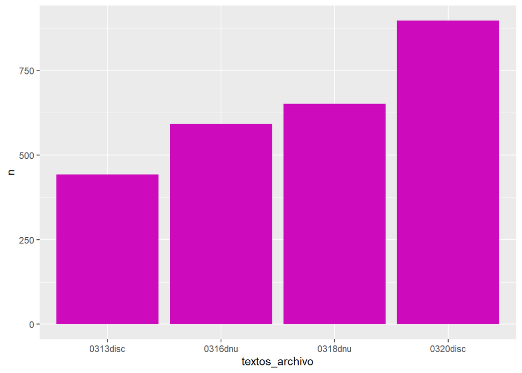

```r
mensajes_pal_limpio %>%
               group_by(textos_archivo) %>%
              count(palabra, sort = T) %>%
               ggplot() +
               geom_bar(aes(textos_archivo,
                            n),
                        stat = 'identity', fill = 6)
```

Salvaremos el gráficos con:

```r
ggsave("mensajes_pal_limpio.png")
```

Otro gráfico que se puede realizar es observando las palabras más frecuentes de los textos, para ello primero, se llamará a `mensajes_pal_limpio`, se pedirá que cuente las ocurrencias, ordenadas de mayor a menor; en la tercera línea se indicará que filtre las ocurrencias mayores a 10, pues se han eliminado las palabras vacías. Como se explicó antes, al crear una nueva tabla interna se debe indicar con `mutate`, la nueva columna, que almacenará los nuevos datos. Luego se indicarán los parámetros del gráfico. *Aclaración,* `ggplot` *une sus parámetros con* `+`; el argumento `fill` hará que cada palabra tenga un color determinado, `stat` indicará que las barras tendrán la altura según `n`. Las líneas siguientes presentarán parámetros para título, ubicación de leyenda y etiquetas en los ejes; y mediante `coord_flip()` se asegura que el eje **Y** se imprima de forma horizontal.

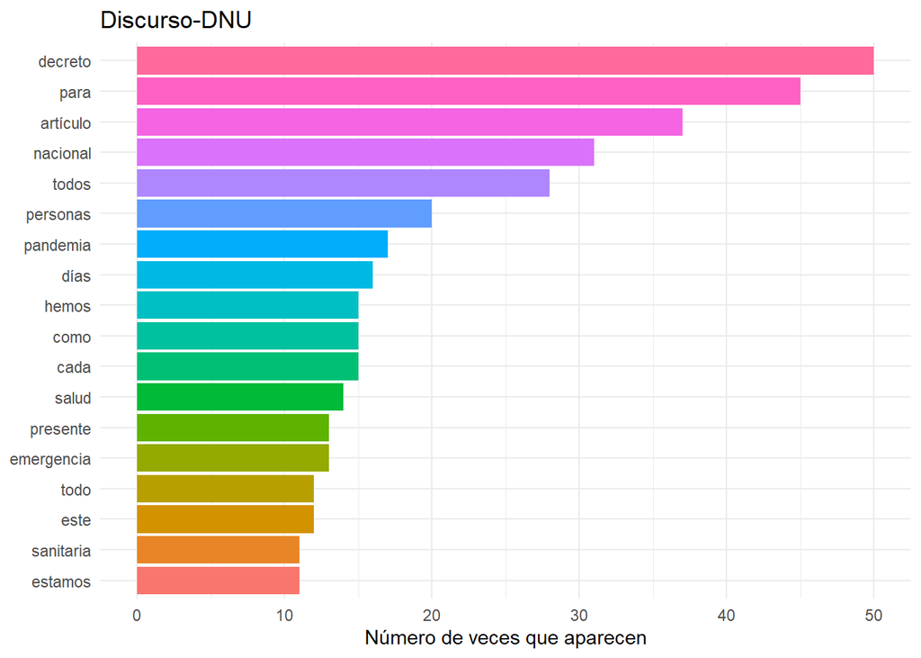

```r
mensajes_pal_limpio %>%
    count(palabra, sort = T) %>%
    filter(n > 10) %>%
    mutate(palabra = reorder(palabra, n)) %>%
    ggplot(aes(x = palabra, y = n, fill = palabra)) +
    geom_bar(stat="identity") +
    theme_minimal() +
    theme(legend.position = "none") +
    ylab("Número de veces que aparecen") +
    xlab(NULL) +
    ggtitle("Discurso-DNU") +
    coord_flip()
```

```r
ggsave("mensajes_palabras.png")
```

```r
mensajes_frecuencias <- mensajes_palabras %>%
      count (palabra, sort = TRUE) %>%
      mutate (relativa = n / sum(n)) %>%
       mutate(Clasificacion = row_number())

mensajes_frecuencias
```

| palabra | n | relativa | Clasificacion |
| --- | --- | --- | --- |
| de | 343 | 0.0671364259 | 1 |
| la | 208 | 0.0407124682 | 2 |
| que | 191 | 0.0373850069 | 3 |
| el | 156 | 0.0305343511 | 4 |
| a | 147 | 0.0287727540 | 5 |
| y | 142 | 0.0277940889 | 6 |
| en | 129 | 0.0252495596 | 7 |
| los | 93 | 0.0182031709 | 8 |
| del | 72 | 0.0140927775 | 9 |
| las | 61 | 0.0119397142 | 10 |

[output cut: 1333 more lines]

Para generar el gráfico con dichos datos, se utilizará la tabla anterior, y se indicará en la tercera línea, mediante `geom_line` la forma en que va a realizar la línea del gráfico; y en las últimas dos, se indicará que en ambos ejes se usará la escala logarítimica.

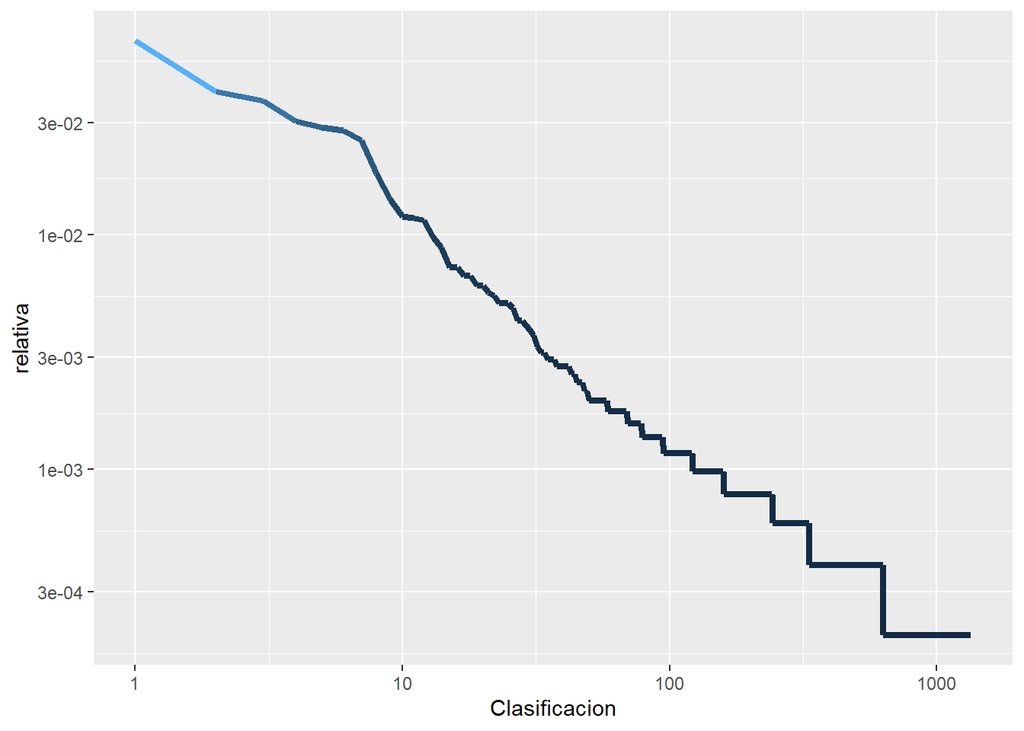

```r
mensajes_frecuencias %>%
      ggplot(aes(Clasificacion, relativa, color = n)) +
      geom_line(size = 1.5, alpha = 1.8, show.legend = FALSE) +
      scale_x_log10() +
      scale_y_log10()
```

Una cuestión final, que es a modo de comparación con la clase anterior, y las herramientas que se presentaron, veremos como se puede realizar gráficos de **nube de palabras**. Para lo cual, deberás utilizar los datos de `mensajes_limpio` y cargaras la librería `wordcloud`. Primero, indicaremos que seleccione los datos para realizar la nube, luego mediante `count` se contarán las observaciones, indicando que las clasifique, con el argumento `with` podremos realizar la evaluación de la función `wordcloud`, primero le diremos que tome las palabras de determinada frecuencia, `max.words`, que nos indicará que elija los términos más con determinada frecuencia, y por último indicaremos la gama de colores que deseamos (pueden acceder al siguiente [enlace](https://colorbrewer2.org/#type=sequential&scheme=BuGn&n=3) para una paleta de colores completa).

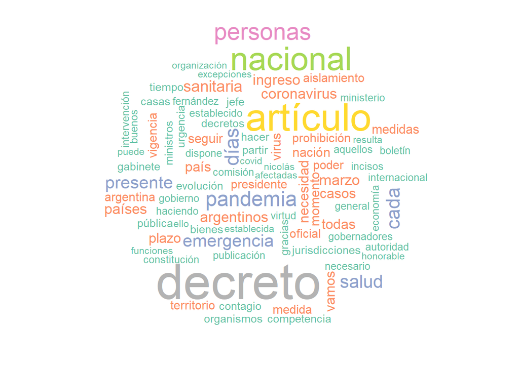

```r
library("wordcloud")
mensajes_limpio %>%
  count(palabra, sort = T) %>%
  with(wordcloud(palabra,
                 n,
                 max.words = 85,
                 color = brewer.pal(8, "Set2")))
```

Finalmente, te propongo que realices los análisis y gráficos anteriores para las distintas tablas de mensajes, donde se han realizado la limpieza de palabras vacías y compares los resultados. Como ejercitación extra podrías, además, intentar observar los cambios al considerar todos los archivos del corpus.

[^1]: Accesibles desde http://www.infoleg.gob.ar/?page_id=112 y https://www.casarosada.gob.ar/informacion/discursos?start=200. Por otra parte, cabe destacar que se podría realizar una automatización de la obtención y descarga de cada uno de los textos, pero no será visto en este curso, para lo cual recomiendo, si interesa este proceso: [link1](https://zenscrape.com/web-scraping-r/) y [link2](https://www.r-bloggers.com/2020/07/tutorial-web-scraping-of-multiple-pages-using-r/).
[^2]: Tidyverse está compuesto por los paquetes: readr, dplyr, ggplot2, tibble, tidyr, purr, stringr, forcats. Puede obtener más información en: [tidyverse](https://www.tidyverse.org/). Asimismo, cabe destacar que lo más sencillo es instalar el paquete completo **tidyverse** pero también puede instalar las librerias específicas según su necesidad. Recomiendo además leer si tuviese más dudas: https://rpubs.com/paraneda/tidyverse.
[^3]: Tidytext es una librería que permite realizar mineo de texto mediante la herramientas tidy. Estas son muy utilizadas en la minería para la adecuación, limpieza y visualización de los datos. Para más información puede acceder a: https://www.tidytextmining.com/ o tidytext.
[^4]: Para más información sobre ggplot2, véase Wilkinson, L., D. Wills, D. Rope, A. Norton, and R. Dubbs (2005. The Grammar of Graphics. Statistics and Computing. New York: Springer.